# [Project1] Urban Ministries of Durham

BIOS611, Fall 2019

Ji-Eun Park

10/6/2019

### Background

[figure not shown]

**Urban Ministries of Durham (UMD)** is the organization that provides food, clothing, shelter and supportive services to our neighbors in need. They have been serving communities around in order to carry out this mission while providing a welcoming, caring and compassionate environment that affirms the dignity of our guests, volunteers and staff.

UMD was developed and is partially supported by a diverse group: many individuals, foundations, corporations, and government. In particular, their main services include food, shelter, clothing and supportive services for over 6,000 men, women and children annually.

### Project Goal and Research Questions

- **Goal**: To better understand the UMD’s primary services such food, clothing, diapers, and etc. and to see if there is any trend and pattern over time. In particular, we are interested in the questions below:
  1. How many clients visted more than one single year (i.e. multiple times over the years)?
  2. Are there specific service/goods in higher demand recently?
  3. Are there specific trends in higher demand in certain seasons?
  4. Are there higher demand of support from the organization than before? Should the organization be prepared for more budget in order to support the future demands?

### Data source

The original UMD dataset consists of 79838 observations with 18 variables. The details of each variable was summarized below:

| Variable | Details |
| --- | --- |
| `Date` | Date |
| `Client File Number` | Unique ID |
| `Client File Merge` | Unique ID from other document before merge |
| `Bus Tickets (Number of)` | Number of Bus Tickets Provided |
| `Notes of Service` | Details in words |
| `Food Provided for` | Number of Food Provided |
| `Food Pounds` | Weight of Food Provided in lbs |
| `Clothing Items` | Number of Clothes Supported |
| `Diapers` | Number of Diapers Provided |
| `School Kits` | Number of School Kits Provided |
| `Hygiene Kits` | Number of Hygiene Kits Provided |
| `Referrals` | Referrals, other detail information |
| `Financial Support` | Monetary support provided in dollars |
| `Type of Bill Paid` | Housing or utilities bill paid (e.g. rent, electricity, and etc.) |
| `Payer of Support` | Who paid/supported |
| `Field1`, `Field2`, `Field3` | Other detail information |

### Exploratory Data Analysis

Since the dataset was messy, the data got thorugh preprocessing process. All the missing values are imputed by 0 and the below is the summary of the preprocessed dataset.

Data Frame Summary

dat

**Dimensions**: 79787 x 10  
**Duplicates**: 0

| **No** | **Variable** | **Stats / Values** | **Freqs (% of Valid)** | **Graph** | **Valid** | **Missing** |
| --- | --- | --- | --- | --- | --- | --- |
| 1 | Date [Date] | min : 1990-12-28 med : 2012-06-29 max : 2019-08-31 range : 28y 8m 3d | 4561 distinct values |  | 79787 (100%) | 0 (0%) |
| 2 | ClientFileNum [integer] | Mean (sd) : 7288.8 (4682.6) min < med < max: 1 < 6969 < 16792 IQR (CV) : 7974 (0.6) | 15347 distinct values |  | 79787 (100%) | 0 (0%) |
| 3 | BusTicketCount [numeric] | Mean (sd) : 0 (0.1) min < med < max: 0 < 0 < 10 IQR (CV) : 0 (29.7) | 0 : 79656 ( 99.8% ) 1 : 34 ( 0.0% ) 2 : 54 ( 0.1% ) 3 : 3 ( 0.0% ) 4 : 26 ( 0.0% ) 5 : 4 ( 0.0% ) 6 : 4 ( 0.0% ) 7 : 1 ( 0.0% ) 8 : 4 ( 0.0% ) 10 : 1 ( 0.0% ) |  | 79787 (100%) | 0 (0%) |
| 4 | FoodProvided [numeric] | Mean (sd) : 2 (6.4) min < med < max: 0 < 1 < 1151 IQR (CV) : 3 (3.3) | 40 distinct values |  | 79787 (100%) | 0 (0%) |
| 5 | Food_lbs [numeric] | Mean (sd) : 21.4 (1593.9) min < med < max: 0 < 15 < 450121 IQR (CV) : 25 (74.4) | 61 distinct values |  | 79787 (100%) | 0 (0%) |
| 6 | Clothing [numeric] | Mean (sd) : 7.3 (7.3) min < med < max: 0 < 6 < 247 IQR (CV) : 8 (1) | 88 distinct values |  | 79787 (100%) | 0 (0%) |
| 7 | Diapers [numeric] | Mean (sd) : 0.2 (18.8) min < med < max: 0 < 0 < 5303 IQR (CV) : 0 (94.2) | 28 distinct values |  | 79787 (100%) | 0 (0%) |
| 8 | SchoolKit [numeric] | Mean (sd) : 0 (0.2) min < med < max: 0 < 0 < 25 IQR (CV) : 0 (68.9) | 16 distinct values |  | 79787 (100%) | 0 (0%) |
| 9 | HygieneKit [numeric] | Mean (sd) : 0 (0.2) min < med < max: 0 < 0 < 8 IQR (CV) : 0 (5.2) | 0 : 76740 ( 96.2% ) 1 : 2996 ( 3.8% ) 2 : 37 ( 0.1% ) 3 : 4 ( 0.0% ) 4 : 4 ( 0.0% ) 5 : 3 ( 0.0% ) 6 : 2 ( 0.0% ) 8 : 1 ( 0.0% ) |  | 79787 (100%) | 0 (0%) |
| 10 | FinSupport [numeric] | Mean (sd) : 0.4 (8.5) min < med < max: 0 < 0 < 450 IQR (CV) : 0 (20.5) | 173 distinct values |  | 79787 (100%) | 0 (0%) |

Generated by summarytools 0.9.3 ([R](https://www.r-project.org/) version 3.6.0)  
2019-10-07

### 1. How many clients did they visit more than one single year (i.e. multiple times over the years)?

> - Around 87% of the clients have visited and got aided less than three time. This indicates that usually our clients do not have constant help.

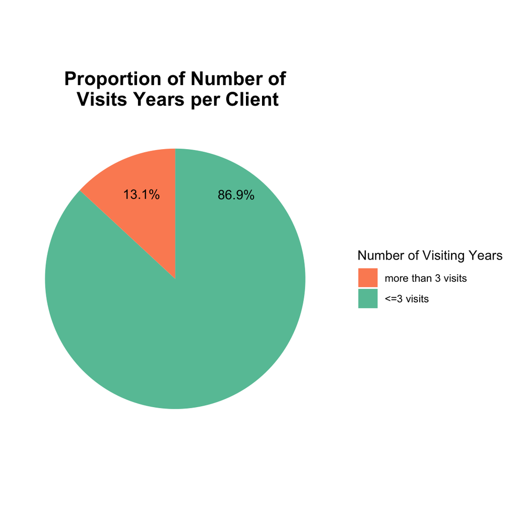

### 2. Are there specific service/goods in higher demand recently?

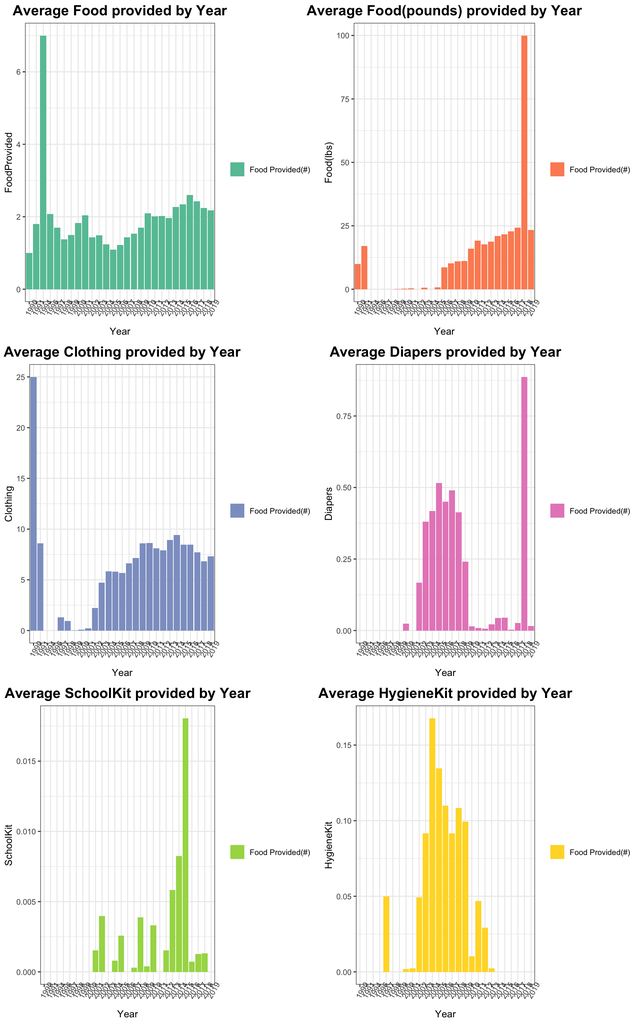

### 3. Are there specific trends in higher demand in certain seasons?

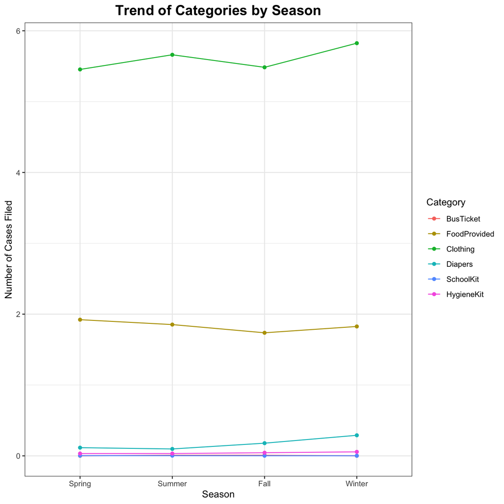

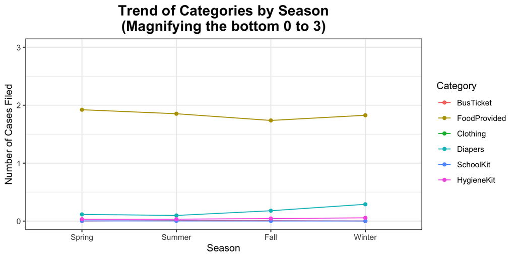

[output not shown]

| Season | pm.p.Tukey | pm.p | wilcoxon.p.holm | wilcoxon.p |
| --- | --- | --- | --- | --- |
| Summer - Spring | 1.000 | 0.959 | 1.000 | 0.984 |
| Fall - Spring | 1.000 | 0.960 | 1.000 | 0.820 |
| Winter - Spring | 1.000 | 0.991 | 1.000 | 0.975 |
| Fall - Summer | 1.000 | 0.916 | 1.000 | 0.918 |
| Winter - Summer | 1.000 | 0.966 | 1.000 | 0.975 |
| Winter - Fall | 1.000 | 0.950 | 1.000 | 0.893 |

| Season | n | n.complete | mean.sd | pval.anova | median.IQR | pval.KW |
| --- | --- | --- | --- | --- | --- | --- |
| Spring | 24.000 | 24 | 0.12 +/- 0.17 |  | 0.01 (0,0.19) |  |
| Summer | 24.000 | 24 | 0.1 +/- 0.16 |  | 0.01 (0,0.1) |  |
| Fall | 24.000 | 24 | 0.17 +/- 0.29 |  | 0.01 (0,0.38) |  |
| Winter | 24.000 | 24 | 0.29 +/- 0.68 | 0.32 | 0.01 (0,0.39) | 0.896 |

| Season | pm.p.Tukey | pm.p | wilcoxon.p.holm | wilcoxon.p |
| --- | --- | --- | --- | --- |
| Summer - Spring | 0.998 | 0.665 | 1.000 | 0.872 |
| Fall - Spring | 0.960 | 0.420 | 1.000 | 0.604 |
| Winter - Spring | 0.425 | 0.243 | 1.000 | 0.602 |
| Fall - Summer | 0.902 | 0.261 | 1.000 | 0.649 |
| Winter - Summer | 0.321 | 0.190 | 1.000 | 0.530 |
| Winter - Fall | 0.731 | 0.449 | 1.000 | 0.874 |

### 4. Are there higher demand of support from the organization than before? Should the organization be prepared for more budget in order to support the future demands?

> - We could identify that the number of clients (organizations) are getting more and increasing as time goes by. Thus, it demonstartes that more support and donation will be necessry in order to meet expected higher demand of support in the future.
> - When it comes to financial support, it recorded the peak in mid 2000s. However, it is getting more and more decreasing. We could say that service/good support is increasing, while financial support is decreasing over time. Thus, the preparation for the future higher demand should be item-centric rather than monetary centric.

[figure not shown]

### Conclusion

- Majority of clients do not have constant visitings. This can be either due to the service/goods provided or hopefully, they are no longer in need of help.
- Following up with the clients when visits are discontinued might help improve the service of UMD.

### Suggestion

**1. Improved data entry/management system in need**

- Too many NA and 0 values, and this makes it difficult for people to understand what homeless people needs.
- For those who are in charge of entering the data, we could consider standardizing the data entry form.
- For an updated form, it will be better if we could use drop-down menu as much as possible so that we could expect to prevent typos and missings.

**2. Item-centric rather than monetary-centric**

- Identified that the monetary (financial) support were decreasing since mid 2000s, whereas the goods support are increasing over time.
- Thus, it is important to understand (or predict) which items should be most in need for the clients in the future study.